# Ford GoBike System Slide Deck

## Dataset Overview

This data set includes information about individual rides made in a bike-sharing system covering the greater San Francisco Bay area.

Features :

- Trip Duration (seconds)
- Start Time and Date
- End Time and Date
- Start Station ID
- Start Station Name
- Start Station Latitude
- Start Station Longitude
- End Station ID
- End Station Name
- End Station Latitude
- End Station Longitude
- Bike ID
- User Type (Subscriber or Customer – “Subscriber” = Member or “Customer” = Casual)

## Trips taken through the week

> It seems like people tend to take trips on Thursdays and rest on weekends

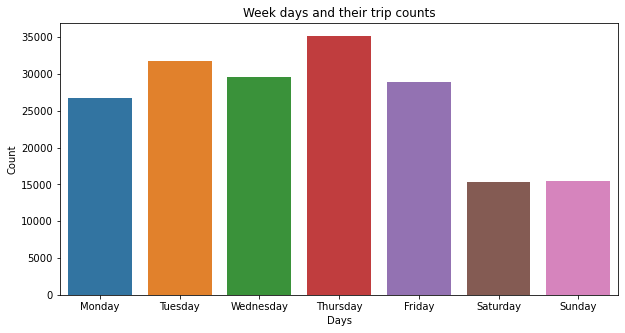

## Which Gender is more active ?

> It seems like people who identify as 'other' spend more time on their trips followed by Females and then Males

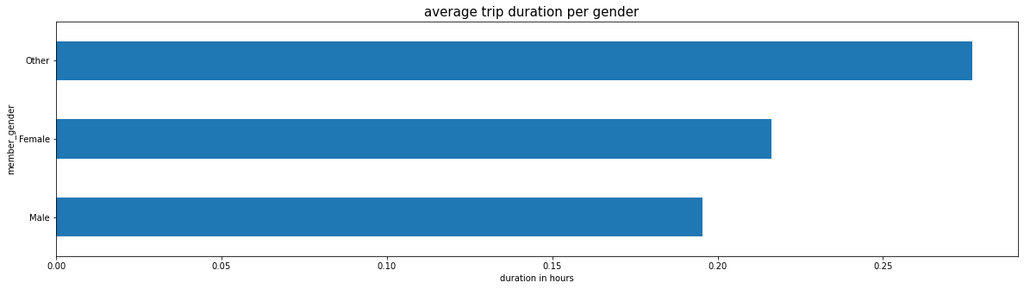

## Average trip duration for each Gender per day

> Most of the time Females tend to spend more on their trips but it is not always the case for Saturdays since Males tend to make an exception

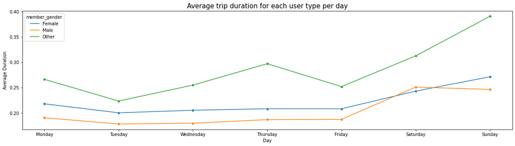

## Which user spends the most time on his trips ?

> It seems like Customers tend to spend on average more time than Subscribers during these trips

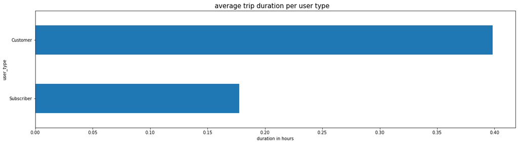

## What are the days where different user types are more active ?

> Seems like customers prefer to attend trips on weekends more than the rest of the weekdays

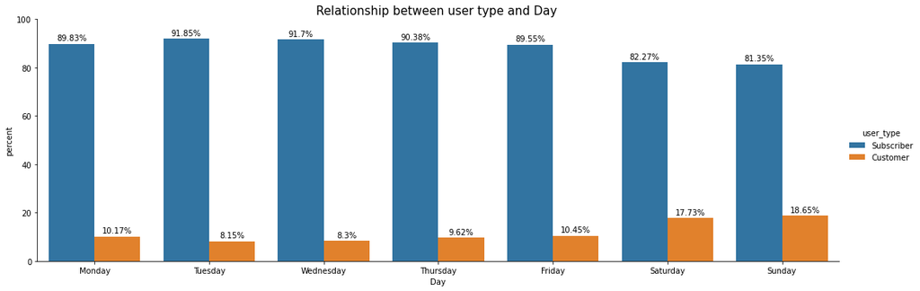

## Average trip duration for each user type per day

> Customers represent the minority in our data , yet they still spend the most time on trips , specifically on weekends since they tend to be more presents in those 2 days

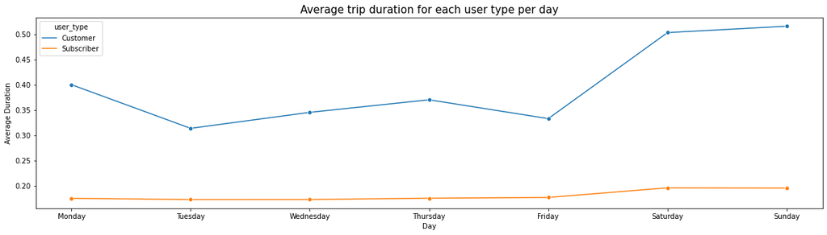